# Part I - Ford GoBike System Data

## Introduction

> This dataset collects data from the S.Francisco Bay Area bike-sharing system rides. The data referes to February 2019 and has information about the users, like age, the start and end point of each rental and the initial and final station where the bikes were rented.

## Preliminary Wrangling

```python
# import all packages and set plots to be embedded inline
import numpy as np
import pandas as pd
import matplotlib.pyplot as plt
import seaborn as sns
import math
```

> Load in your dataset and describe its properties through the questions below. Try and motivate your exploration goals through this section.

```python
#read csv and show first lines of the dataframe:
df=pd.read_csv("201902-fordgobike-tripdata.csv")
```

```python
#Create a copy:
bikes=df.copy()
bikes.head()
```

|  | duration_sec | start_time | end_time | start_station_id | start_station_name | start_station_latitude | start_station_longitude | end_station_id | end_station_name | end_station_latitude | end_station_longitude | bike_id | user_type | member_birth_year | member_gender | bike_share_for_all_trip |
| --- | --- | --- | --- | --- | --- | --- | --- | --- | --- | --- | --- | --- | --- | --- | --- | --- |
| 0 | 52185 | 2019-02-28 17:32:10.1450 | 2019-03-01 08:01:55.9750 | 21.0 | Montgomery St BART Station (Market St at 2nd St) | 37.789625 | -122.400811 | 13.0 | Commercial St at Montgomery St | 37.794231 | -122.402923 | 4902 | Customer | 1984.0 | Male | No |
| 1 | 42521 | 2019-02-28 18:53:21.7890 | 2019-03-01 06:42:03.0560 | 23.0 | The Embarcadero at Steuart St | 37.791464 | -122.391034 | 81.0 | Berry St at 4th St | 37.775880 | -122.393170 | 2535 | Customer | NaN | NaN | No |
| 2 | 61854 | 2019-02-28 12:13:13.2180 | 2019-03-01 05:24:08.1460 | 86.0 | Market St at Dolores St | 37.769305 | -122.426826 | 3.0 | Powell St BART Station (Market St at 4th St) | 37.786375 | -122.404904 | 5905 | Customer | 1972.0 | Male | No |
| 3 | 36490 | 2019-02-28 17:54:26.0100 | 2019-03-01 04:02:36.8420 | 375.0 | Grove St at Masonic Ave | 37.774836 | -122.446546 | 70.0 | Central Ave at Fell St | 37.773311 | -122.444293 | 6638 | Subscriber | 1989.0 | Other | No |
| 4 | 1585 | 2019-02-28 23:54:18.5490 | 2019-03-01 00:20:44.0740 | 7.0 | Frank H Ogawa Plaza | 37.804562 | -122.271738 | 222.0 | 10th Ave at E 15th St | 37.792714 | -122.248780 | 4898 | Subscriber | 1974.0 | Male | Yes |

```python
#Check data:
bikes.info()
```

```
<class 'pandas.core.frame.DataFrame'>
RangeIndex: 183412 entries, 0 to 183411
Data columns (total 16 columns):
 #   Column                   Non-Null Count   Dtype
---  ------                   --------------   -----
 0   duration_sec             183412 non-null  int64
 1   start_time               183412 non-null  object
 2   end_time                 183412 non-null  object
 3   start_station_id         183215 non-null  float64
 4   start_station_name       183215 non-null  object
 5   start_station_latitude   183412 non-null  float64
 6   start_station_longitude  183412 non-null  float64
 7   end_station_id           183215 non-null  float64
 8   end_station_name         183215 non-null  object
 9   end_station_latitude     183412 non-null  float64
 10  end_station_longitude    183412 non-null  float64
 11  bike_id                  183412 non-null  int64
 12  user_type                183412 non-null  object
 13  member_birth_year        175147 non-null  float64
 14  member_gender            175147 non-null  object
 15  bike_share_for_all_trip  183412 non-null  object
dtypes: float64(7), int64(2), object(7)
memory usage: 22.4+ MB
```

```python
#Ckeck shape of the dataframe:
bikes.shape
```

```
(183412, 16)
```

```python
#Check nulls:
bikes.isnull().sum()
```

```
duration_sec                  0
start_time                    0
end_time                      0
start_station_id            197
start_station_name          197
start_station_latitude        0
start_station_longitude       0
end_station_id              197
end_station_name            197
end_station_latitude          0
end_station_longitude         0
bike_id                       0
user_type                     0
member_birth_year          8265
member_gender              8265
bike_share_for_all_trip       0
dtype: int64
```

```python
#Filter nulls:
bikes.loc[bikes.start_station_id.isnull()]
```

|  | duration_sec | start_time | end_time | start_station_id | start_station_name | start_station_latitude | start_station_longitude | end_station_id | end_station_name | end_station_latitude | end_station_longitude | bike_id | user_type | member_birth_year | member_gender | bike_share_for_all_trip |
| --- | --- | --- | --- | --- | --- | --- | --- | --- | --- | --- | --- | --- | --- | --- | --- | --- |
| 475 | 1709 | 2019-02-28 20:55:53.9320 | 2019-02-28 21:24:23.7380 | NaN | NaN | 37.40 | -121.94 | NaN | NaN | 37.40 | -121.93 | 4211 | Customer | 1991.0 | Female | No |
| 1733 | 1272 | 2019-02-28 18:32:34.2730 | 2019-02-28 18:53:46.7270 | NaN | NaN | 37.40 | -121.94 | NaN | NaN | 37.41 | -121.96 | 4174 | Subscriber | 1980.0 | Male | No |
| 3625 | 142 | 2019-02-28 17:10:46.5290 | 2019-02-28 17:13:09.4310 | NaN | NaN | 37.41 | -121.95 | NaN | NaN | 37.41 | -121.96 | 4283 | Subscriber | 1988.0 | Male | No |
| 4070 | 585 | 2019-02-28 16:28:45.9340 | 2019-02-28 16:38:31.3320 | NaN | NaN | 37.39 | -121.93 | NaN | NaN | 37.40 | -121.92 | 4089 | Subscriber | 1984.0 | Male | Yes |
| 5654 | 509 | 2019-02-28 12:30:17.1310 | 2019-02-28 12:38:46.3290 | NaN | NaN | 37.40 | -121.92 | NaN | NaN | 37.39 | -121.93 | 4089 | Subscriber | 1984.0 | Male | Yes |
| ... | ... | ... | ... | ... | ... | ... | ... | ... | ... | ... | ... | ... | ... | ... | ... | ... |
| 176154 | 1447 | 2019-02-02 12:03:04.5440 | 2019-02-02 12:27:12.2670 | NaN | NaN | 37.40 | -121.93 | NaN | NaN | 37.40 | -121.93 | 4249 | Customer | 1984.0 | Male | No |
| 179730 | 309 | 2019-02-01 12:59:45.9690 | 2019-02-01 13:04:55.4260 | NaN | NaN | 37.40 | -121.94 | NaN | NaN | 37.40 | -121.93 | 4249 | Customer | 1987.0 | Female | No |
| 179970 | 659 | 2019-02-01 12:17:37.6750 | 2019-02-01 12:28:37.0140 | NaN | NaN | 37.41 | -121.96 | NaN | NaN | 37.41 | -121.94 | 4092 | Subscriber | 1999.0 | Female | No |
| 180106 | 2013 | 2019-02-01 11:33:55.1470 | 2019-02-01 12:07:28.9400 | NaN | NaN | 37.40 | -121.94 | NaN | NaN | 37.40 | -121.94 | 4251 | Customer | 1990.0 | Female | No |
| 181201 | 312 | 2019-02-01 09:26:34.8030 | 2019-02-01 09:31:46.9210 | NaN | NaN | 37.40 | -121.93 | NaN | NaN | 37.40 | -121.93 | 4208 | Subscriber | 1987.0 | Male | No |

197 rows × 16 columns

```python
#Filter nulls:
bikes.loc[bikes.member_gender.isnull()]
```

|  | duration_sec | start_time | end_time | start_station_id | start_station_name | start_station_latitude | start_station_longitude | end_station_id | end_station_name | end_station_latitude | end_station_longitude | bike_id | user_type | member_birth_year | member_gender | bike_share_for_all_trip |
| --- | --- | --- | --- | --- | --- | --- | --- | --- | --- | --- | --- | --- | --- | --- | --- | --- |
| 1 | 42521 | 2019-02-28 18:53:21.7890 | 2019-03-01 06:42:03.0560 | 23.0 | The Embarcadero at Steuart St | 37.791464 | -122.391034 | 81.0 | Berry St at 4th St | 37.775880 | -122.393170 | 2535 | Customer | NaN | NaN | No |
| 13 | 915 | 2019-02-28 23:49:06.0620 | 2019-03-01 00:04:21.8670 | 252.0 | Channing Way at Shattuck Ave | 37.865847 | -122.267443 | 244.0 | Shattuck Ave at Hearst Ave | 37.873676 | -122.268487 | 5101 | Subscriber | NaN | NaN | No |
| 28 | 650 | 2019-02-28 23:43:27.5030 | 2019-02-28 23:54:18.4510 | 258.0 | University Ave at Oxford St | 37.872355 | -122.266447 | 263.0 | Channing Way at San Pablo Ave | 37.862827 | -122.290231 | 4784 | Customer | NaN | NaN | No |
| 53 | 3418 | 2019-02-28 22:41:16.3620 | 2019-02-28 23:38:14.3630 | 11.0 | Davis St at Jackson St | 37.797280 | -122.398436 | 11.0 | Davis St at Jackson St | 37.797280 | -122.398436 | 319 | Customer | NaN | NaN | No |
| 65 | 926 | 2019-02-28 23:17:05.8530 | 2019-02-28 23:32:32.6820 | 13.0 | Commercial St at Montgomery St | 37.794231 | -122.402923 | 81.0 | Berry St at 4th St | 37.775880 | -122.393170 | 2951 | Subscriber | NaN | NaN | No |
| ... | ... | ... | ... | ... | ... | ... | ... | ... | ... | ... | ... | ... | ... | ... | ... | ... |
| 183354 | 449 | 2019-02-01 01:35:07.6630 | 2019-02-01 01:42:36.8780 | 244.0 | Shattuck Ave at Hearst Ave | 37.873676 | -122.268487 | 253.0 | Haste St at College Ave | 37.866418 | -122.253799 | 5430 | Customer | NaN | NaN | No |
| 183356 | 795 | 2019-02-01 01:25:50.3660 | 2019-02-01 01:39:05.9500 | 368.0 | Myrtle St at Polk St | 37.785434 | -122.419622 | 125.0 | 20th St at Bryant St | 37.759200 | -122.409851 | 5400 | Subscriber | NaN | NaN | No |
| 183363 | 673 | 2019-02-01 01:12:24.4200 | 2019-02-01 01:23:37.6450 | 75.0 | Market St at Franklin St | 37.773793 | -122.421239 | 133.0 | Valencia St at 22nd St | 37.755213 | -122.420975 | 5166 | Customer | NaN | NaN | No |
| 183371 | 196 | 2019-02-01 01:08:38.6410 | 2019-02-01 01:11:54.9490 | 58.0 | Market St at 10th St | 37.776619 | -122.417385 | 75.0 | Market St at Franklin St | 37.773793 | -122.421239 | 2395 | Customer | NaN | NaN | No |
| 183402 | 122 | 2019-02-01 00:17:32.2580 | 2019-02-01 00:19:34.9380 | 119.0 | 18th St at Noe St | 37.761047 | -122.432642 | 120.0 | Mission Dolores Park | 37.761420 | -122.426435 | 4326 | Subscriber | NaN | NaN | No |

8265 rows × 16 columns

I decided to drop the null values, they represent about 4% of the data, but I think it's better for the analysis to drop them.

```python
# Removing nulls:
bikes=bikes.dropna()

#checking that there're no null values:
bikes.isnull().sum()
```

```
duration_sec               0
start_time                 0
end_time                   0
start_station_id           0
start_station_name         0
start_station_latitude     0
start_station_longitude    0
end_station_id             0
end_station_name           0
end_station_latitude       0
end_station_longitude      0
bike_id                    0
user_type                  0
member_birth_year          0
member_gender              0
bike_share_for_all_trip    0
dtype: int64
```

```python
#Change the datatypes of start_time and end_time to be dates:
bikes["start_time"] = pd.to_datetime(bikes["start_time"])
bikes["end_time"] = pd.to_datetime(bikes["end_time"])
```

```python
#Cheking dtypes:
bikes.dtypes
```

```
duration_sec                        int64
start_time                 datetime64[ns]
end_time                   datetime64[ns]
start_station_id                  float64
start_station_name                 object
start_station_latitude            float64
start_station_longitude           float64
end_station_id                    float64
end_station_name                   object
end_station_latitude              float64
end_station_longitude             float64
bike_id                             int64
user_type                          object
member_birth_year                 float64
member_gender                      object
bike_share_for_all_trip            object
dtype: object
```

```python
#Checking duplicates:
bikes.duplicated().sum()
```

```
0
```

```python
#Checking uniqueness of the data:
bikes.nunique()
```

```
duration_sec                 4429
start_time                 174941
end_time                   174939
start_station_id              329
start_station_name            329
start_station_latitude        329
start_station_longitude       329
end_station_id                329
end_station_name              329
end_station_latitude          329
end_station_longitude         329
bike_id                      4607
user_type                       2
member_birth_year              75
member_gender                   3
bike_share_for_all_trip         2
dtype: int64
```

```python
# Checking if each station id only has one station name:
# Group by 'start_station_id' and collect unique 'start_station_name' for each group
grouped = bikes.groupby('start_station_id')['start_station_name'].unique()

# Check if any group has more than one unique 'station_name'
conflicts = grouped[grouped.apply(len) > 1]

# Print conflicts
for start_station_id, start_station_name in conflicts.items():
    print(f"Conflict found for start_station_id {start_station_id}: {', '.join(start_station_name)}")
```

```python
#Doing the same for the end_station_id and end_station_name:
grouped = bikes.groupby('end_station_id')['end_station_name'].unique()

# Check if any group has more than one unique 'station_name'
conflicts = grouped[grouped.apply(len) > 1]

# Print conflicts
for end_station_id, end_station_name in conflicts.items():
    print(f"Conflict found for start_station_id {end_station_id}: {', '.join(end_station_name)}")
```

There are 329 different stations, 329 id and 329 station names. As checked above, each station id has one station name, so I can drop the station_id columns and keep only the names of the stations. I'll do that later when dropping the columns that won't be used in the analysis.

```python
#Checking why there are 3 genders:
bikes.member_gender.unique()
```

```
array(['Male', 'Other', 'Female'], dtype=object)
```

```python
#Looking for the number of rows with other gender
bikes.loc[bikes.member_gender=="Other"]
```

|  | duration_sec | start_time | end_time | start_station_id | start_station_name | start_station_latitude | start_station_longitude | end_station_id | end_station_name | end_station_latitude | end_station_longitude | bike_id | user_type | member_birth_year | member_gender | bike_share_for_all_trip |
| --- | --- | --- | --- | --- | --- | --- | --- | --- | --- | --- | --- | --- | --- | --- | --- | --- |
| 3 | 36490 | 2019-02-28 17:54:26.010 | 2019-03-01 04:02:36.842 | 375.0 | Grove St at Masonic Ave | 37.774836 | -122.446546 | 70.0 | Central Ave at Fell St | 37.773311 | -122.444293 | 6638 | Subscriber | 1989.0 | Other | No |
| 8 | 1570 | 2019-02-28 23:41:48.790 | 2019-03-01 00:07:59.715 | 10.0 | Washington St at Kearny St | 37.795393 | -122.404770 | 127.0 | Valencia St at 21st St | 37.756708 | -122.421025 | 6548 | Subscriber | 1988.0 | Other | No |
| 131 | 1187 | 2019-02-28 22:39:58.560 | 2019-02-28 22:59:46.206 | 262.0 | West St at University Ave | 37.869967 | -122.286533 | 240.0 | Haste St at Telegraph Ave | 37.866043 | -122.258804 | 5649 | Subscriber | 1993.0 | Other | No |
| 135 | 544 | 2019-02-28 22:48:12.730 | 2019-02-28 22:57:17.080 | 356.0 | Valencia St at Clinton Park | 37.769188 | -122.422285 | 34.0 | Father Alfred E Boeddeker Park | 37.783988 | -122.412408 | 6065 | Subscriber | 1991.0 | Other | No |
| 190 | 515 | 2019-02-28 22:28:11.347 | 2019-02-28 22:36:46.389 | 58.0 | Market St at 10th St | 37.776619 | -122.417385 | 321.0 | 5th St at Folsom | 37.780146 | -122.403071 | 5234 | Subscriber | 1981.0 | Other | No |
| ... | ... | ... | ... | ... | ... | ... | ... | ... | ... | ... | ... | ... | ... | ... | ... | ... |
| 183346 | 312 | 2019-02-01 02:06:04.566 | 2019-02-01 02:11:17.122 | 175.0 | 49th St at Telegraph Ave | 37.835946 | -122.262366 | 166.0 | College Ave at Alcatraz Ave | 37.851376 | -122.252523 | 5450 | Subscriber | 1997.0 | Other | Yes |
| 183349 | 527 | 2019-02-01 01:48:54.755 | 2019-02-01 01:57:42.540 | 213.0 | 32nd St at Adeline St | 37.823847 | -122.281193 | 158.0 | Shattuck Ave at Telegraph Ave | 37.833279 | -122.263490 | 1172 | Subscriber | 1997.0 | Other | Yes |
| 183378 | 659 | 2019-02-01 00:53:36.143 | 2019-02-01 01:04:35.371 | 47.0 | 4th St at Harrison St | 37.780955 | -122.399749 | 67.0 | San Francisco Caltrain Station 2 (Townsend St... | 37.776639 | -122.395526 | 4960 | Subscriber | 1985.0 | Other | No |
| 183381 | 426 | 2019-02-01 00:48:54.159 | 2019-02-01 00:56:00.474 | 230.0 | 14th St at Mandela Pkwy | 37.810743 | -122.291415 | 213.0 | 32nd St at Adeline St | 37.823847 | -122.281193 | 3535 | Subscriber | 1997.0 | Other | Yes |
| 183389 | 184 | 2019-02-01 00:43:56.556 | 2019-02-01 00:47:01.009 | 66.0 | 3rd St at Townsend St | 37.778742 | -122.392741 | 47.0 | 4th St at Harrison St | 37.780955 | -122.399749 | 4960 | Subscriber | 1985.0 | Other | No |

3647 rows × 16 columns

```python
#Calculate the travelled distance in km:
def travelled_distance(start_station_latitude, end_station_latitude, start_station_longitude, end_station_longitude):
    # Convert latitude and longitude from degrees to radians
    lat1 = start_station_latitude*(math.pi/180)
    lat2 = end_station_latitude*(math.pi/180)
    long1 = start_station_longitude*(math.pi/180)
    long2 = end_station_longitude*(math.pi/180)

    #Haversine Formula:
    dlong = long2 - long1
    dlat = lat2 - lat1
    a = math.sin(dlat/2)**2 + math.cos(lat1) * math.cos(lat2) * math.sin(dlong/2)**2
    c = 2 * math.atan2(math.sqrt(a), math.sqrt(1 - a))
    distance = 6371 * c  # Radius of the Earth in kilometers
    return distance
```

```python
#Create a column with the caluculated travelled distance:
bikes['distance']=bikes.apply(lambda row: travelled_distance(row['start_station_latitude'], row['end_station_latitude'], row['start_station_longitude'], row['end_station_longitude']), axis=1)
```

```python
#Checking the statistics:
bikes.describe()
```

|  | duration_sec | start_station_id | start_station_latitude | start_station_longitude | end_station_id | end_station_latitude | end_station_longitude | bike_id | member_birth_year | distance |
| --- | --- | --- | --- | --- | --- | --- | --- | --- | --- | --- |
| count | 174952.000000 | 174952.000000 | 174952.000000 | 174952.000000 | 174952.000000 | 174952.000000 | 174952.000000 | 174952.000000 | 174952.000000 | 174952.000000 |
| mean | 704.002744 | 139.002126 | 37.771220 | -122.351760 | 136.604486 | 37.771414 | -122.351335 | 4482.587555 | 1984.803135 | 1.690049 |
| std | 1642.204905 | 111.648819 | 0.100391 | 0.117732 | 111.335635 | 0.100295 | 0.117294 | 1659.195937 | 10.118731 | 1.096957 |
| min | 61.000000 | 3.000000 | 37.317298 | -122.453704 | 3.000000 | 37.317298 | -122.453704 | 11.000000 | 1878.000000 | 0.000000 |
| 25% | 323.000000 | 47.000000 | 37.770407 | -122.411901 | 44.000000 | 37.770407 | -122.411647 | 3799.000000 | 1980.000000 | 0.910443 |
| 50% | 510.000000 | 104.000000 | 37.780760 | -122.398279 | 101.000000 | 37.781010 | -122.397437 | 4960.000000 | 1987.000000 | 1.429829 |
| 75% | 789.000000 | 239.000000 | 37.797320 | -122.283093 | 238.000000 | 37.797673 | -122.286533 | 5505.000000 | 1992.000000 | 2.224010 |
| max | 84548.000000 | 398.000000 | 37.880222 | -121.874119 | 398.000000 | 37.880222 | -121.874119 | 6645.000000 | 2001.000000 | 69.469241 |

```python
#Filtering the dataframe to see when distance is 0:
bikes.loc[bikes.distance==0]
```

|  | duration_sec | start_time | end_time | start_station_id | start_station_name | start_station_latitude | start_station_longitude | end_station_id | end_station_name | end_station_latitude | end_station_longitude | bike_id | user_type | member_birth_year | member_gender | bike_share_for_all_trip | distance |
| --- | --- | --- | --- | --- | --- | --- | --- | --- | --- | --- | --- | --- | --- | --- | --- | --- | --- |
| 19 | 874 | 2019-02-28 23:43:05.183 | 2019-02-28 23:57:39.796 | 180.0 | Telegraph Ave at 23rd St | 37.812678 | -122.268773 | 180.0 | Telegraph Ave at 23rd St | 37.812678 | -122.268773 | 5629 | Customer | 1978.0 | Male | No | 0.0 |
| 27 | 408 | 2019-02-28 23:48:08.282 | 2019-02-28 23:54:56.930 | 78.0 | Folsom St at 9th St | 37.773717 | -122.411647 | 78.0 | Folsom St at 9th St | 37.773717 | -122.411647 | 5410 | Subscriber | 1982.0 | Male | No | 0.0 |
| 34 | 471 | 2019-02-28 23:42:43.361 | 2019-02-28 23:50:34.446 | 133.0 | Valencia St at 22nd St | 37.755213 | -122.420975 | 133.0 | Valencia St at 22nd St | 37.755213 | -122.420975 | 5559 | Subscriber | 1992.0 | Male | No | 0.0 |
| 55 | 3478 | 2019-02-28 22:39:35.020 | 2019-02-28 23:37:33.342 | 11.0 | Davis St at Jackson St | 37.797280 | -122.398436 | 11.0 | Davis St at Jackson St | 37.797280 | -122.398436 | 1846 | Subscriber | 1995.0 | Male | No | 0.0 |
| 56 | 3140 | 2019-02-28 22:44:53.503 | 2019-02-28 23:37:14.090 | 11.0 | Davis St at Jackson St | 37.797280 | -122.398436 | 11.0 | Davis St at Jackson St | 37.797280 | -122.398436 | 3040 | Subscriber | 1983.0 | Female | No | 0.0 |
| ... | ... | ... | ... | ... | ... | ... | ... | ... | ... | ... | ... | ... | ... | ... | ... | ... | ... |
| 183317 | 1476 | 2019-02-01 02:45:04.744 | 2019-02-01 03:09:41.184 | 345.0 | Hubbell St at 16th St | 37.766483 | -122.398279 | 345.0 | Hubbell St at 16th St | 37.766483 | -122.398279 | 5224 | Subscriber | 1967.0 | Male | No | 0.0 |
| 183318 | 877 | 2019-02-01 02:53:15.995 | 2019-02-01 03:07:53.058 | 385.0 | Woolsey St at Sacramento St | 37.850578 | -122.278175 | 385.0 | Woolsey St at Sacramento St | 37.850578 | -122.278175 | 4913 | Subscriber | 1987.0 | Male | No | 0.0 |
| 183326 | 5713 | 2019-02-01 01:02:55.168 | 2019-02-01 02:38:09.002 | 31.0 | Raymond Kimbell Playground | 37.783813 | -122.434559 | 31.0 | Raymond Kimbell Playground | 37.783813 | -122.434559 | 5366 | Subscriber | 1972.0 | Male | No | 0.0 |
| 183350 | 874 | 2019-02-01 01:41:43.414 | 2019-02-01 01:56:17.552 | 253.0 | Haste St at College Ave | 37.866418 | -122.253799 | 253.0 | Haste St at College Ave | 37.866418 | -122.253799 | 3232 | Subscriber | 1995.0 | Male | Yes | 0.0 |
| 183380 | 943 | 2019-02-01 00:43:11.550 | 2019-02-01 00:58:55.217 | 31.0 | Raymond Kimbell Playground | 37.783813 | -122.434559 | 31.0 | Raymond Kimbell Playground | 37.783813 | -122.434559 | 5343 | Subscriber | 1972.0 | Male | No | 0.0 |

3458 rows × 17 columns

```python
#Dropping rows where distance = 0
bikes= bikes.loc[bikes.distance!=0]
```

```python
#Ckecking:
bikes.loc[bikes.distance==0]
```

|  | duration_sec | start_time | end_time | start_station_id | start_station_name | start_station_latitude | start_station_longitude | end_station_id | end_station_name | end_station_latitude | end_station_longitude | bike_id | user_type | member_birth_year | member_gender | bike_share_for_all_trip | distance |
| --- | --- | --- | --- | --- | --- | --- | --- | --- | --- | --- | --- | --- | --- | --- | --- | --- | --- |

```python
#Check the dataset dates, by creating a column of year, month and day:
bikes["year"]=bikes["start_time"].dt.year
bikes["month"]=bikes["start_time"].dt.month
bikes["day"]=bikes["start_time"].dt.day
```

```python
bikes.year.unique()
```

```
array([2019])
```

```python
bikes.month.unique()
```

```
array([2])
```

```python
bikes.day.unique()
```

```
array([28, 27, 26, 25, 24, 23, 22, 21, 20, 19, 18, 17, 16, 15, 14, 13, 12,
       11, 10,  9,  8,  7,  6,  5,  4,  3,  2,  1])
```

```python
#Create calculated colums with the weekday of the rentals, and hour of the rentals:
bikes['start_weekday'] = bikes['start_time'].dt.day_name()
bikes['end_weekday'] = bikes['end_time'].dt.day_name()
bikes["start_hour"]=bikes['start_time'].dt.hour
bikes["end_hour"]=bikes['end_time'].dt.hour
```

In this dataframe we have data from February of 2019.

```python
#Calculating the age of the members in the time they rent the bike:
bikes["member_age"]=bikes["start_time"].dt.year - bikes["member_birth_year"]
```

```python
#Calculate duration in minutes:
bikes["duration_min"]=bikes["duration_sec"]/60
```

```python
#Drop columns that won't be used in the analysis:
bikes.drop(labels=["duration_sec", "year","month", "day","start_station_id", "end_station_id", "bike_share_for_all_trip", "start_station_latitude", "end_station_latitude", "start_station_longitude", "end_station_longitude", "member_birth_year", "bike_id"], axis=1, inplace= True)
```

```python
#Reorganize the order of the columns:
bikes=bikes[["start_time", "end_time", "start_weekday", "end_weekday", "start_hour", "end_hour", "duration_min", "distance", "start_station_name", "end_station_name", "member_age", "member_gender","user_type"]]
bikes.head(4)
```

|  | start_time | end_time | start_weekday | end_weekday | start_hour | end_hour | duration_min | distance | start_station_name | end_station_name | member_age | member_gender | user_type |
| --- | --- | --- | --- | --- | --- | --- | --- | --- | --- | --- | --- | --- | --- |
| 0 | 2019-02-28 17:32:10.145 | 2019-03-01 08:01:55.975 | Thursday | Friday | 17 | 8 | 869.750000 | 0.544709 | Montgomery St BART Station (Market St at 2nd St) | Commercial St at Montgomery St | 35.0 | Male | Customer |
| 2 | 2019-02-28 12:13:13.218 | 2019-03-01 05:24:08.146 | Thursday | Friday | 12 | 5 | 1030.900000 | 2.704545 | Market St at Dolores St | Powell St BART Station (Market St at 4th St) | 47.0 | Male | Customer |
| 3 | 2019-02-28 17:54:26.010 | 2019-03-01 04:02:36.842 | Thursday | Friday | 17 | 4 | 608.166667 | 0.260739 | Grove St at Masonic Ave | Central Ave at Fell St | 30.0 | Other | Subscriber |
| 4 | 2019-02-28 23:54:18.549 | 2019-03-01 00:20:44.074 | Thursday | Friday | 23 | 0 | 26.416667 | 2.409301 | Frank H Ogawa Plaza | 10th Ave at E 15th St | 45.0 | Male | Subscriber |

```python
#Checking the info of the final dataset:
bikes.info()
```

```
<class 'pandas.core.frame.DataFrame'>
Int64Index: 171494 entries, 0 to 183411
Data columns (total 13 columns):
 #   Column              Non-Null Count   Dtype
---  ------              --------------   -----
 0   start_time          171494 non-null  datetime64[ns]
 1   end_time            171494 non-null  datetime64[ns]
 2   start_weekday       171494 non-null  object
 3   end_weekday         171494 non-null  object
 4   start_hour          171494 non-null  int64
 5   end_hour            171494 non-null  int64
 6   duration_min        171494 non-null  float64
 7   distance            171494 non-null  float64
 8   start_station_name  171494 non-null  object
 9   end_station_name    171494 non-null  object
 10  member_age          171494 non-null  float64
 11  member_gender       171494 non-null  object
 12  user_type           171494 non-null  object
dtypes: datetime64[ns](2), float64(3), int64(2), object(6)
memory usage: 18.3+ MB
```

```python
#Checking statistics of the final dataframe:
bikes.describe()
```

|  | start_hour | end_hour | duration_min | distance | member_age |
| --- | --- | --- | --- | --- | --- |
| count | 171494.000000 | 171494.000000 | 171494.000000 | 171494.000000 | 171494.000000 |
| mean | 13.445421 | 13.594890 | 11.368458 | 1.724127 | 34.195278 |
| std | 4.738131 | 4.750714 | 25.572231 | 1.081121 | 10.084265 |
| min | 0.000000 | 0.000000 | 1.016667 | 0.013287 | 18.000000 |
| 25% | 9.000000 | 9.000000 | 5.383333 | 0.938188 | 27.000000 |
| 50% | 14.000000 | 14.000000 | 8.466667 | 1.454683 | 32.000000 |
| 75% | 17.000000 | 18.000000 | 12.983333 | 2.249000 | 39.000000 |
| max | 23.000000 | 23.000000 | 1409.133333 | 69.469241 | 141.000000 |

### What is/are the main feature(s) of interest in your dataset?

> The main features are: duration of the trip, distance travelled, weekdays and hours with more rentals.

### What features in the dataset do you think will help support your investigation into your feature(s) of interest?

> Features like member's age, member's gender and type of user.

## Univariate Exploration

#### What is the distribution by member's age?

```python
#Create a function for the boxplot:

def myboxplot(df, xvar, xlab, title, color):
    #Plot:
    plot = sns.boxplot(data=df, x=xvar, color=color)
    #Add Title:
    plot.set_title(title)
    # Add x-axis label (legend)
    plot.set_xlabel(xlab)
    #Show the plot:
    plt.show()
```

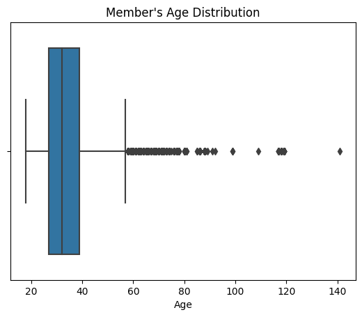

```python
#Call myboxplot function to create a boxplot to check age distribution:
myboxplot(bikes, "member_age", "Age", "Member's Age Distribution", "tab:blue")
```

As we can see in the boxplot above, there are some outliers in age of the members. Ages up to 100 years old are not possible so I'll drop this data from the dataset.

```python
#Dropping rows with age <100:
bikes= bikes.loc[bikes.member_age<=100]
```

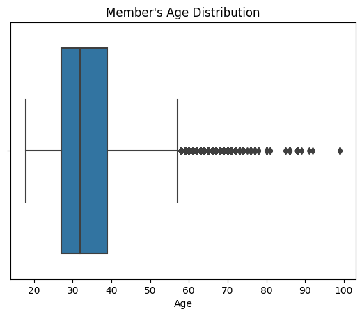

```python
#Checking results:
myboxplot(bikes, "member_age", "Age", "Member's Age Distribution", "tab:blue")
```

Although there're still many outliers, we can see that most ages are between late 20's and late 30's years old. To get another visualisation I'll creat an histogram.

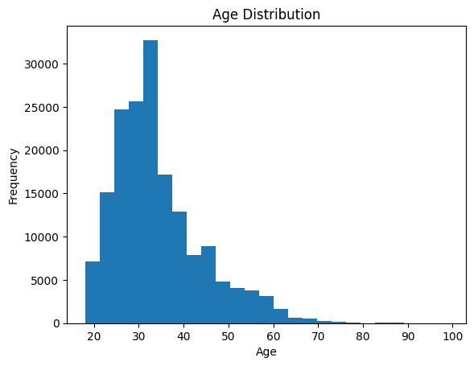

```python
#Create an histogram:

plt.hist(data=bikes, x='member_age', bins=25, color='tab:blue')

# Add labels and title:
plt.xlabel('Age')
plt.ylabel('Frequency')
plt.title('Age Distribution')

# Show the plot:
plt.show();
```

With this histogram, I can confirm the boxplot results. The majority of the members are about 30's years old. To be more specific I can look at the statistics.

```python
mean_age=bikes["member_age"].mean()
print("The mean age of the members is: ", mean_age)
```

```
The mean age of the members is:  34.159751957158356
```

#### What is the distribution by member's gender?

```python
#Count Plot:
def mycountplot(df, xvar, xlab, ylab, title):
    #Plot:
    plot = sns.countplot(data=df, x=xvar)
    #Add Title:
    plot.set_title(title)
    # Add x-axis label (legend)
    plot.set_xlabel(xlab)
    # Add y-axis label (legend)
    plot.set_ylabel(ylab)
    #Show the plot:
    plt.show()
```

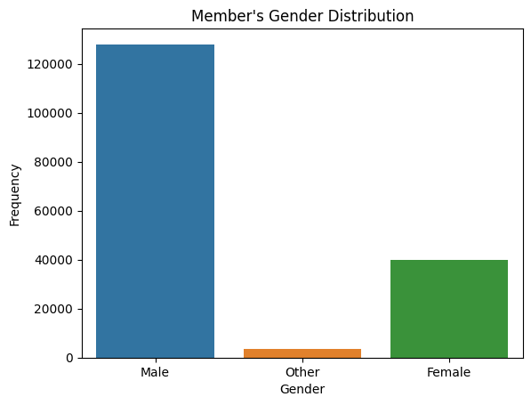

```python
#Call mycountplot function to create a boxplot to check age distribution:
mycountplot(bikes, "member_gender", "Gender", "Frequency", "Member's Gender Distribution");
```

I can conclude that most of the members are male.

#### Distibution of user type:

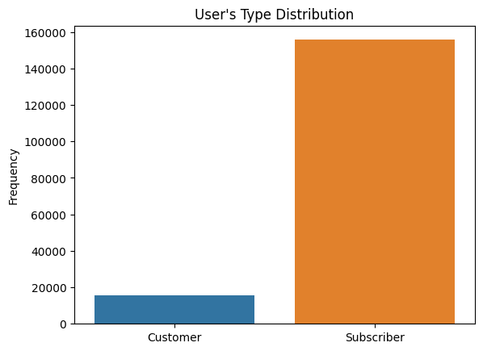

```python
#Call mycountplot function to create a boxplot to check age distribution:
mycountplot(bikes, "user_type", "", "Frequency", "User's Type Distribution");
```

As shown in the countplot above, most of the users of the bike sharing system are subscribers.

#### Are there more rentals in labor weekdays or at the weekend?

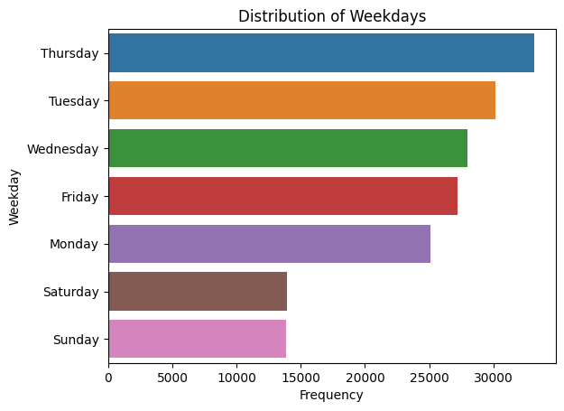

```python
# Plot an horizontal bar plot:
# Count the frequency of unique values in the `start_weekday` column:
weekday_counts = bikes['start_weekday'].value_counts()
# Set a decreasing order:
order=weekday_counts.index
# Plot an horizontal bar chart:
sns.countplot(data=bikes, y='start_weekday', order=order);
# Add Title:
plt.title('Distribution of Weekdays')
plt.xlabel('Frequency')
plt.ylabel('Weekday');
```

Most of the rentals start in a Thursday. Between weekdays the results are similar but it's clear that there are less rentals at the weekend.

#### What is the time of the day with more rentals?

```python
#Filtering the data for the labour days:
bikes1 = bikes.loc[(bikes['start_weekday'] != "Saturday") & (bikes['start_weekday'] != "Sunday")]
```

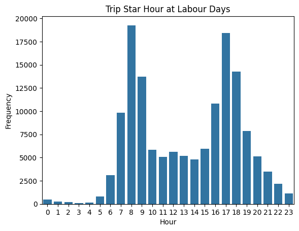

```python
# Create a countplot to check the rental start hour distribution in labour days:
sns.countplot(data=bikes1, x='start_hour', color="tab:blue");
plt.title('Trip Star Hour at Labour Days')
plt.xlabel('Hour');
plt.ylabel('Frequency');
```

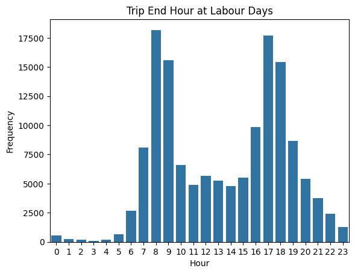

```python
# Create a countplot to check the rental end hour distribution:
sns.countplot(data=bikes1, x='end_hour', color="tab:blue");
plt.title('Trip End Hour at Labour Days')
plt.xlabel('Hour');
plt.ylabel('Frequency');
```

The trip distribution over labour days hours peaks around two timeframes, 8am-9am and 17pm-18pm, during typical rush hours. 75% of the trips start before 17pm and end before 18pm (as seen in the statistics).

```python
#Filtering the data frame to see if there's a difference between labor days and weekends
bikes2 = bikes.loc[(bikes['start_weekday'] == "Saturday") | (bikes['start_weekday'] == "Sunday")]
```

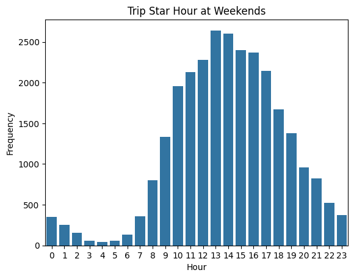

```python
# Create a countplot to check the rental end hour distribution at the weekends:
sns.countplot(data=bikes2, x='start_hour', color="tab:blue");
plt.title('Trip Star Hour at Weekends')
plt.xlabel('Hour');
plt.ylabel('Frequency');
```

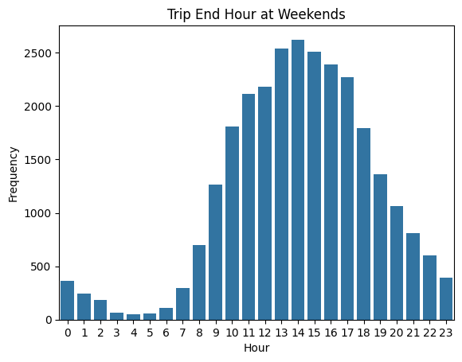

```python
# Create a countplot to check the rental end hour distribution at the weekends:
sns.countplot(data=bikes2, x='end_hour', color="tab:blue");
plt.title('Trip End Hour at Weekends')
plt.xlabel('Hour');
plt.ylabel('Frequency');
```

The distribution of the trip hours at the weekends is not so concentrated in three or 4 four hours (like at labour days) but in a period of time from 10 am to 18 pm.

#### Distribution of the rental duration:

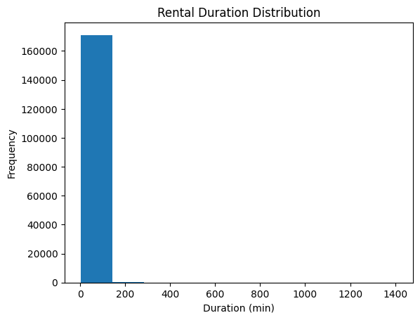

```python
# Create an histogram:
plt.hist(data=bikes, x='duration_min', color='tab:blue');

# Add labels and title:
plt.xlabel('Duration (min)')
plt.ylabel('Frequency')
plt.title('Rental Duration Distribution')

# Show the plot:
plt.show();
```

I tried with different bins number, but the results are not good, so I limited the x-axis to 0 to 60 min interval.

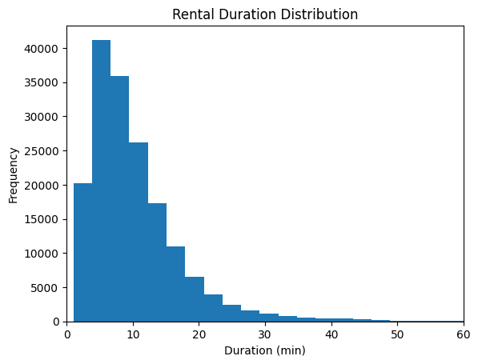

```python
# Create a histogram:
plt.hist(data=bikes, x='duration_min', bins=500, color='tab:blue')

# Add labels and title:
plt.xlabel('Duration (min)')
plt.ylabel('Frequency')
plt.title('Rental Duration Distribution')

# Set x-axis limits:
min_limit = 0
max_limit = 60
plt.xlim(min_limit, max_limit)

# Show the plot:
plt.show()
```

```python
#Checking statistics of the duration of the trips.
bikes.duration_min.describe()
```

```
count    171422.000000
mean         11.368638
std          25.577094
min           1.016667
25%           5.383333
50%           8.466667
75%          12.983333
max        1409.133333
Name: duration_min, dtype: float64
```

As we can see in the statistics and the histogram, the majority of the trips have a duration of less than 10 minutes.

#### Distribution of distance travelled:

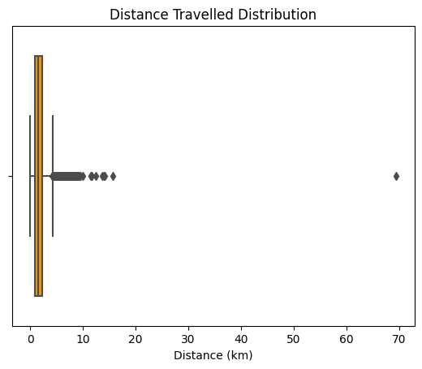

```python
#Call myboxplot function to create a boxplot to check age distribution:
myboxplot(bikes, "distance", "Distance (km)", "Distance Travelled Distribution", "orange")
```

As seen in the boxplot, the distance covered per rental varies from less than a km to 70km (which is an outlier) but most of the trips are from less than 2km.

```python
bikes.describe()
```

|  | start_hour | end_hour | duration_min | distance | member_age |
| --- | --- | --- | --- | --- | --- |
| count | 171422.000000 | 171422.000000 | 171422.000000 | 171422.000000 | 171422.000000 |
| mean | 13.445433 | 13.594906 | 11.368638 | 1.723980 | 34.159752 |
| std | 4.738252 | 4.750835 | 25.577094 | 1.080823 | 9.936060 |
| min | 0.000000 | 0.000000 | 1.016667 | 0.013287 | 18.000000 |
| 25% | 9.000000 | 9.000000 | 5.383333 | 0.938188 | 27.000000 |
| 50% | 14.000000 | 14.000000 | 8.466667 | 1.454683 | 32.000000 |
| 75% | 17.000000 | 18.000000 | 12.983333 | 2.248697 | 39.000000 |
| max | 23.000000 | 23.000000 | 1409.133333 | 69.469241 | 99.000000 |

### Discuss the distribution(s) of your variable(s) of interest. Were there any unusual points? Did you need to perform any transformations?

> Most of the rentals are in labour days rather than in the weekends. The trip distribution over labour days hours peaks around two timeframes, 8am-9am and 17pm-18pm, during typical rush hours, while at the weekends is more spread in an interval from the morning till the afternoon.

> Most of the trips last less than 10 minutes and the mean distance covered is about 2km.

> I found some interesting aspects about the data. There are many outliers both in the distance and duration of the trips, for example 70km covered in a rental and 1409 minutes (almost 24h). For this reason it was difficult to perform a good histogram in the distribution of the duration of the rentals and I has to set limits to see the distribution between 0 to 60 min.

### Of the features you investigated, were there any unusual distributions? Did you perform any operations on the data to tidy, adjust, or change the form of the data? If so, why did you do this?

> On the features investigated I found some odd aspects. Ages of more than 100 years old, with a maximum of 141 years old person. I dropped the rows with ages of 100 years old and more because it's not feasible that someone with more than 100 years old is riding a bike sharing system. The average age of the members is 34 years old.

> The majority of the members are male and subscribers instead of customers.

## Bivariate Exploration

> In this section, investigate relationships between pairs of variables in your data. Make sure the variables that you cover here have been introduced in some fashion in the previous section (univariate exploration).

#### Distance travalled and duration of the rental per member's age:

```python
def scatterplot(df, xvar, yvar, xlab, ylab, color):
    # Calculate correlation:
    corr = df[[xvar, yvar]].corr().iloc[0, 1]

    # Set the figure size:
    plt.figure(figsize=(8, 6))

   # Plot:
    plt.scatter(data=df, x=xvar, y=yvar, label=f'Correlation: {corr:0.3f}', color=color)

    # Labels:
    plt.xlabel(xlab)
    plt.ylabel(ylab)

    # Add title and format it:
    plt.title(f'Relationship between {ylab} and {xlab}'.title())

    # Add legend:
    plt.legend()

    # Show the plot:
    plt.show()
```

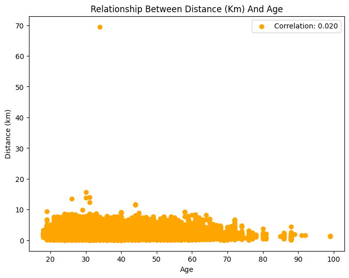

```python
# call scatterplot function to see if there's a linear relationship between distance travelled and the age of the member:
scatterplot(bikes, "member_age", "distance", "Age", "Distance (km)", "orange")
```

The scatterplot show no linear relationship between age and distance travelled.

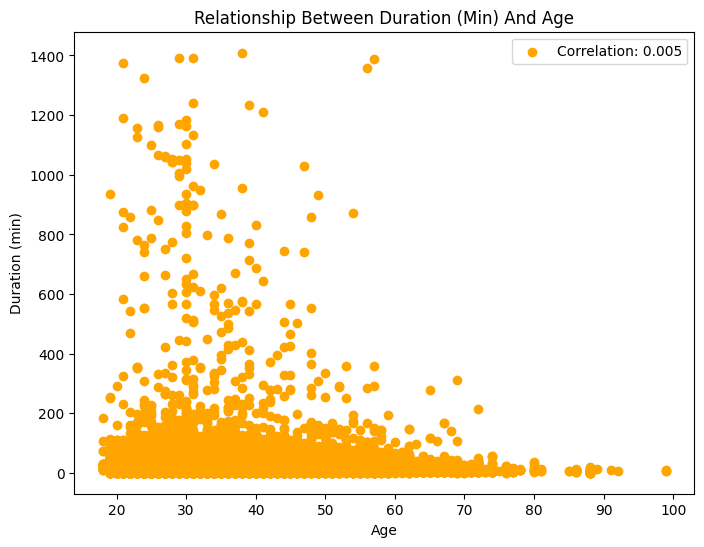

```python
# call scatterplot function to see if there's a linear relationship between distance travelled and the age of the member:
scatterplot(bikes, "member_age", "duration_min", "Age", "Duration (min)", "orange")
```

The scatterplot show no linear relationship between age and distance duration of the trip.

#### How does the duration and distance vary between genders:

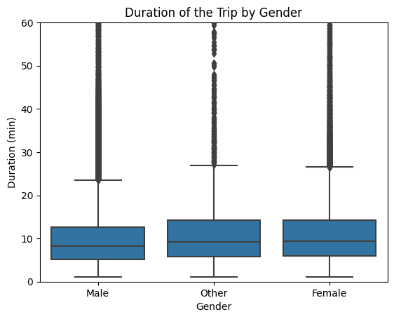

```python
#Create a boxplot and set limits to duration to achieve a better visualization:
sns.boxplot(data=bikes, x='member_gender', y='duration_min', color="tab:blue");
plt.xlabel('Gender');
plt.ylabel('Duration (min)')
plt.title("Duration of the Trip by Gender")
# Set y-axis limits:
min_limit = 0
max_limit = 60
plt.ylim(min_limit, max_limit);
```

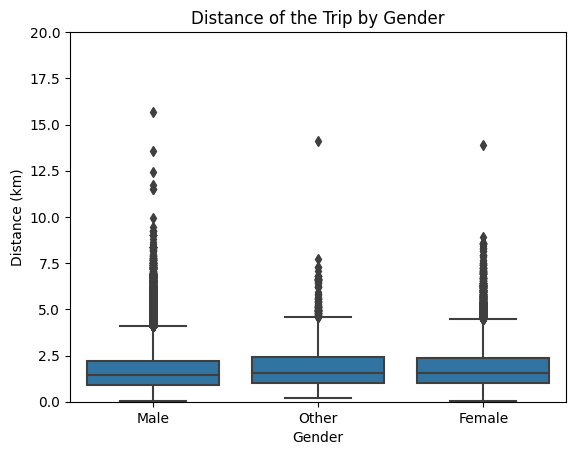

```python
#Create a boxplot and set limits to distance to achieve a better visualization:
sns.boxplot(data=bikes, x='member_gender', y='distance', color="tab:blue");
plt.xlabel('Gender');
plt.ylabel("Distance (km)");
plt.title("Distance of the Trip by Gender")
# Set y-axis limits:
min_limit = 0
max_limit = 20
plt.ylim(min_limit, max_limit);
```

Altough there's not a big difference, male's trips last a little less and travel shorter trips than female and other gender.

#### How does member's age varies by weekdays:

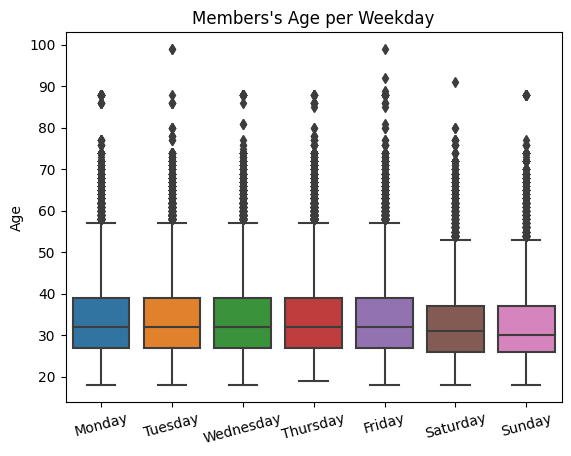

```python
#Create a boxplot:

weekday_order=["Monday", "Tuesday", "Wednesday", "Thursday", "Friday", "Saturday", "Sunday"]
sns.boxplot(data=bikes, x='start_weekday', y='member_age', order=weekday_order);
plt.ylabel("Age");
plt.xlabel("");
plt.xticks(rotation = 15);
plt.title("Members's Age per Weekday");
```

We can see that during weekends, member's age is a bit younger than at the weekdays (Monday to Friday), so it must be related to usage of the rentals in the week for work, and in the weekend for leisure.

#### Type of user per weekday:

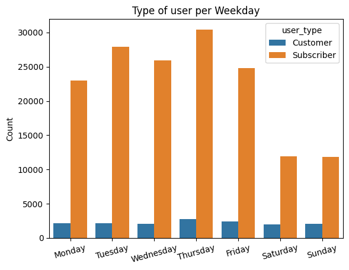

```python
#Countplot:
weekday_order=["Monday", "Tuesday", "Wednesday", "Thursday", "Friday", "Saturday", "Sunday"]
sns.countplot(data=bikes, x='start_weekday', hue='user_type', order=weekday_order);
plt.xlabel('');
plt.ylabel('Count');
plt.xticks(rotation = 15);
plt.title("Type of user per Weekday");
```

Subscribers use the sharing system more often in labour days then in weekends, while in customers we don't see a great variation in labour or weekend days.

#### Average age per type of user:

```python
# Filter the dataframe:
bikes_customer=bikes.loc[bikes.user_type=="Customer"]
# Calculate the mean:
average_age_customer=bikes_customer["member_age"].mean()
# Print results:
print("The average age of the customers is:", average_age_customer)
```

```
The average age of the customers is: 33.674774947328096
```

```python
# Filter the dataframe:
bikes_subs=bikes.loc[bikes.user_type=="Subscriber"]
# Calculate the mean:
average_age_subs=bikes_subs["member_age"].mean()
# Print results:
print("The average age of the subscribers is:", average_age_subs)
```

```
The average age of the subscribers is: 34.2085208559377
```

#### Type of user per gender:

```python
# Use group_by() and size() to get the combination of the number of members from each different gender and user type:
bike_counts = bikes.groupby(['member_gender', 'user_type']).size().reset_index(name='count')
bike_counts
```

|  | member_gender | user_type | count |
| --- | --- | --- | --- |
| 0 | Female | Customer | 4314 |
| 1 | Female | Subscriber | 35604 |
| 2 | Male | Customer | 10917 |
| 3 | Male | Subscriber | 117041 |
| 4 | Other | Customer | 432 |
| 5 | Other | Subscriber | 3114 |

```python
# Use DataFrame.pivot() to rearrange the data, to have vehicle class on rows
bike_counts = bike_counts.pivot(index='member_gender', columns='user_type', values='count')
bike_counts
```

| user_type member_gender | Customer | Subscriber |
| --- | --- | --- |
| Female | 4314 | 35604 |
| Male | 10917 | 117041 |
| Other | 432 | 3114 |

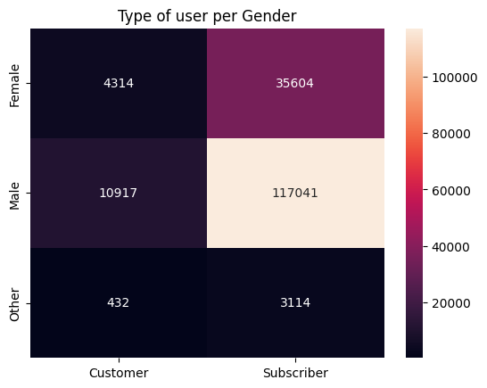

```python
#Plot the heatmap
sns.heatmap(bike_counts,annot=True, fmt='d' );
plt.title("Type of user per Gender")
plt.xlabel('');
plt.ylabel('');
```

The heatplot shows there are much more males than female and other genders and that the number of subcribers is greater than customers in all gender, especialy in males.

### Talk about some of the relationships you observed in this part of the investigation. How did the feature(s) of interest vary with other features in the dataset?

> I tried to find a relationship between member's age and distance travelled and duration of the trip but I didn't find any particular correlation between them.

> Altough there's not a big difference, male's trips last a little less and travel shorter trips than female and other gender.

> During weekends, member's age is a bit younger than in the labour days (Monday to Friday), so it must be related to usage of the rentals in the week for work, and in the weekend for leisure.

### Did you observe any interesting relationships between the other features (not the main feature(s) of interest)?

> Between subscribers and customers the average age of the memmber is similar: about 34 years old, and although in both genders there're more subscribers than customers, in the male gender this is a little bit more accentuated.

## Multivariate Exploration

#### The impact of the weekday on distance and duration of trips for different user types:

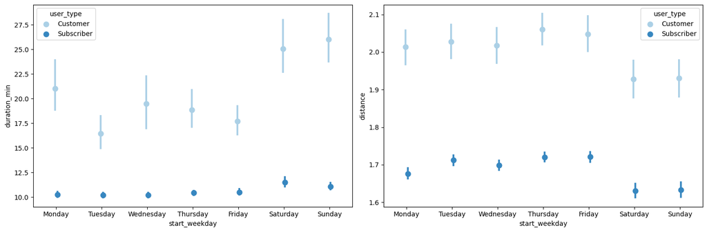

```python
# Define the order of weekdays
weekday_order = ['Monday', 'Tuesday', 'Wednesday', 'Thursday', 'Friday', 'Saturday', 'Sunday']

# Set the overall figure size
plt.figure(figsize=[15, 5])

# Create subplots
plt.subplot(1, 2, 1)
ax = sns.pointplot(data = bikes, x ='start_weekday', y = 'duration_min', hue = 'user_type',
           palette = 'Blues', linestyles = '', dodge = True, order=weekday_order)

plt.subplot(1, 2, 2)
ax = sns.pointplot(data = bikes, x ='start_weekday', y = 'distance', hue = 'user_type',
           palette = 'Blues', linestyles = '', dodge = True, order=weekday_order)

# Adjust layout
plt.tight_layout()
plt.show()
```

As shown above: Customers's trips are much longer in terms of distance and duration than subsccribers's, regardless the day of the week.

For both for customers and subscribers, the trips last longer and for shorter distances at the weekends than at labour days, showing that at the weekend, most people use the bikes for leisure time.

#### The impact of gender and user type in the relationship of distance travelled and member's age:

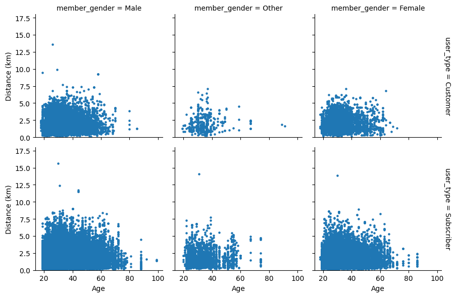

```python
# Scatterplot Distance travelled of each member's age by gender and type of user
g = sns.FacetGrid(data=bikes, col='member_gender', row='user_type', margin_titles=True)
g.map(plt.scatter, 'member_age', 'distance', s=5)  # Adjust the dot size using 's' parameter

# Set x and y-axis labels for all plots
g.set_axis_labels("Age", "Distance (km)")

# Set y-axis limits for all plots
min_limit = 0
max_limit = 18
g.set(ylim=(min_limit, max_limit))

# Show the plot
plt.show()
```

As seen before,there's no linear corelation between age and distance travelled. It's not easy to take accurate and significant conclusions from these plots. However, We can see that between gender, although in average men travell shorter trips, they have a more extended interval of distances travelled than other and female genders, in both type of users, and specially in younger ages (top higher values).

#### Matrix with duration and age:

```python
# Define a dataframe with limits for duration:
df=bikes.loc[bikes.duration_min<=60]
```

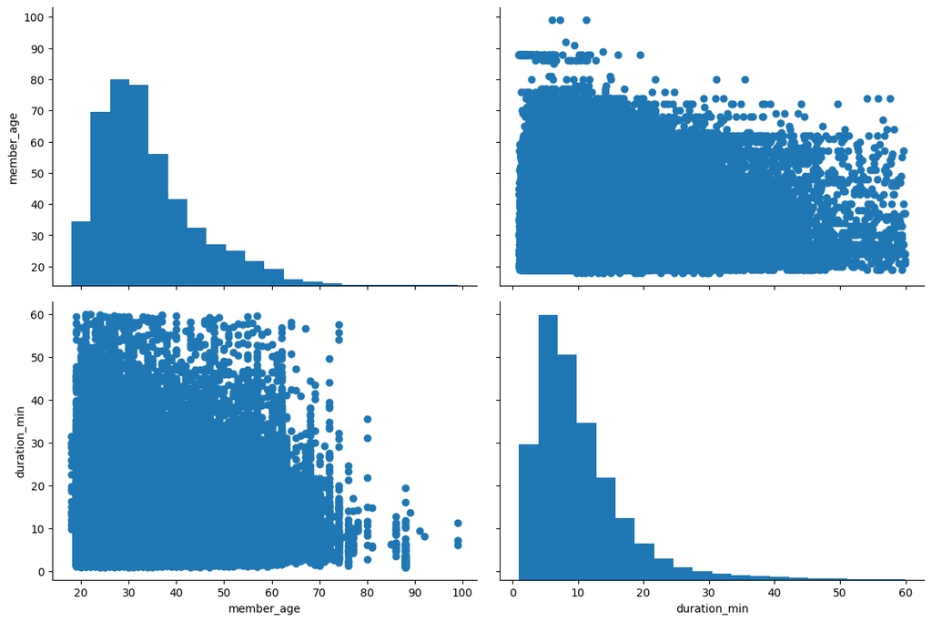

```python
# Plot matrix with duration and member's age
g = sns.PairGrid(data=df, vars=['member_age','duration_min'], height=4, aspect=1.5)
g = g.map_diag(plt.hist, bins=20)
g.map_offdiag(plt.scatter);
```

As seen before,there's no linear corelation between duration and member's age. However, we can observe that older members (+80) tend to travell shorter trips.

### Talk about some of the relationships you observed in this part of the investigation. Were there features that strengthened each other in terms of looking at your feature(s) of interest?

> There's no linear corelation between age and distance or duration of the trip (as seen in the bivariate analysis). But while exploring these features we can observe that between gender men have a more extended interval of distances travelled than other and female genders, in both type of users, and specially in younger ages (top higher values).

### Were there any interesting or surprising interactions between features?

> Customers's trips are much longer in terms of distance and duration than subsccribers's, regardless the day of the week.For both for customers and subscribers, the trips last longer and for shorter distances at the weekends than at labour days, showing that at the weekend, most people use the bikes for leisure time.

> Although it's not surprising, older member's (+80 years old) tend to travell shorter distances and for shorter periods of time.

## Conclusions

> The bike sharing system is by far, more used by men on their 30's, than women or other gender. Men travells shorter trips (in average).

> Most of the users are subscribers, who travell at labour days and in the peak hours: 8am-9am and 17pm-18pm.

> The average age of the members is 34 years old.

> I didn't find any linear relationship between age and distance or duration of the trip.

```python
bikes.to_csv("bikes_final.csv")
```